# R Notebook

# Word Embeded Models

This notebook will use word embeded models to explore the corpus of railroad law.Given the relatively small size and narrow focus of the corpus, I am going to test the usefulness of word embeded models on such a corpus.

```r
library(text2vec)
library(magrittr)
library(wordVectors)
library(tsne)
```

```r
library(ggplot2)
library(tibble)
```

```r
#prep_word2vec("C:/Users/Joshua/Documents/rdata/railroaddata/railroads_documents","rr_docs.txt",lowercase=T)
```

```r
# rr_model = train_word2vec("rr_docs.txt",output="rr_doc_vectors.bin",threads = 6,vectors = 100,window=12)
```

Since I created the vector space model of railroad law previously using the code above, I simply read in this model.This saves an great deal of time as the creation of the model took well over an hour for 397 documents.

```r
rr_model = read.vectors("rr_doc_vectors.bin")
```

```
## Filename ends with .bin, so reading in binary format
```

```
## Reading a word2vec binary file of 99389 rows and 100 columns
```

### Similarity Searching

The first method of exploration I used was similarity searching.To demonstrate one challenge to using this method, I chose the word “buffalo.” As shown below, this returned a list of mostly cities, but I was interested in the animal. Therefore, I needed to perform some addition and subtraction on my word vectors.

```r
rr_model %>% nearest_to(rr_model[["buffalo"]])
```

```
##   buffalo rochester  syracuse     utica      falo   ontario      barb
## 0.0000000 0.2012632 0.2277984 0.2803685 0.2874016 0.2934121 0.3032900
##    hudson      lans  willetts
## 0.3165744 0.3191460 0.3198695
```

Attempting to subtract the cities from the list did not return my desired outcome.

```r
rr_model %>% nearest_to(rr_model[["buffalo"]] - rr_model[[c("ontario","rochester")]])
```

```
##    schlemmer     seaboard philadelphia      delphia       mcdade
##    0.5927157    0.6607016    0.6617937    0.6667922    0.6747821
##  parallelism       skaggs    ticketing    freighter       schlem
##    0.6796515    0.6859656    0.6863341    0.6882537    0.6952039
```

Attempting to add “cattle” removed the cities but did not yield very interesting results.

```r
rr_model %>% nearest_to(rr_model[["buffalo"]] - rr_model[[c("ontario","rochester")]] + rr_model[["cattle"]])
```

```
##    cattle   animals    fences     sheep     stray     fence  straying
## 0.1118414 0.2680012 0.3232248 0.3312358 0.3338269 0.3459414 0.3518763
##   pasture      hogs   inclose
## 0.3551789 0.3569838 0.3613928
```

Therefore, I looked at the similarity between “buffalo” and “cattle” and found that they are not very similar (.0098 cosine similarity).

```r
cosineSimilarity(rr_model[[c("buffalo"),average=F]], rr_model[[c("cattle"), average=F]])
```

```
##              cattle
## buffalo 0.009872652
```

I needed to use a different approach. Below I used the reject function to attempt to filter out unwanted definitions/meanings/semantics of “buffalo.” As the results show, this was also not effective. “Buffalo” the animal is not used enough in the context of an animal in this corpus.

```r
not_that_kind_of_buffalo = rr_model[["buffalo"]] %>%
      reject(rr_model[["city"]]) %>%
      reject(rr_model[["rochester"]]) %>%
      reject(rr_model[["ontario"]])%>%
      reject(rr_model[["utica"]])

rr_model %>% nearest_to(not_that_kind_of_buffalo)
```

```
##       seaboard    parallelism       steamers        buffalo      schlemmer
##      0.6046856      0.6202389      0.6245609      0.6348924      0.6353199
## pennsylvania's       sylvania       truckers          lakes       wheeling
##      0.6570240      0.6574676      0.6699598      0.6761228      0.6775833
```

Next, I looked at another example. Looking at the word “sheep” revealed that the animals included in the corpus are types of cargo.

```r
rr_model %>% nearest_to(rr_model[["sheep"]], 20)
```

```
##        sheep        swine         hogs        goats       cattle
## 1.110223e-16 9.902955e-02 1.109713e-01 1.969225e-01 2.406947e-01
##      animals         cows         pigs       calves        mules
## 2.470230e-01 2.527155e-01 2.553253e-01 2.667693e-01 2.712535e-01
##       horses         mals     inclosed        stray     straying
## 2.811367e-01 3.100431e-01 3.226567e-01 3.251492e-01 3.331614e-01
##      pasture        colts       animal  depasturing    enclosure
## 3.402643e-01 3.434936e-01 3.452895e-01 3.491966e-01 3.493176e-01
```

Interestingly, wool is absent from this above list. Similarly, “sheep” is absent from the similarity search for “wool.”

```r
rr_model %>% nearest_to(rr_model[["wool"]], 20)
```

```
##         wool        hides         meat       cheese        grain
## 3.330669e-16 2.213587e-01 2.452671e-01 2.671053e-01 2.828246e-01
##     potatoes          hay       cotton        flour      leather
## 2.828614e-01 2.846018e-01 2.938557e-01 2.945519e-01 3.014526e-01
##         hops       tallow        fruit   vegetables        sugar
## 3.029880e-01 3.065305e-01 3.272569e-01 3.302758e-01 3.309484e-01
##       stuffs        dried    groceries       canned         eggs
## 3.312986e-01 3.327742e-01 3.328766e-01 3.361479e-01 3.375289e-01
```

Despite the fact that wool and sheep seem unrelated based upon the similarity searching, they do have a fairly high cosine similarity score (0.38).

```r
cosineSimilarity(rr_model[[c("sheep"),average=F]], rr_model[[c("wool"), average=F]])
```

```
##            wool
## sheep 0.3807912
```

The same is true for hides/cows (0.35).

```r
cosineSimilarity(rr_model[[c("cows"),average=F]], rr_model[[c("hides"), average=F]])
```

```
##          hides
## cows 0.3553574
```

Thus, the classic king - man + women = queen example should work for sheep and cows (wool - sheep + cow = hide). However, this is not the case. The results a a jumble of names, perhaps defendents or prosecutors of the cases.

```r
rr_model %>% nearest_to(rr_model[["wool"]] - rr_model[[c("sheep")]] + rr_model[["cow"]], 25)
```

```
##  livingston        bank        slee     wendell  ilollister        wool
##   0.4414807   0.4543948   0.4711656   0.4862499   0.4866044   0.4887075
##     wilmans      upmann        caze    grinnell       bloom    gatliffe
##   0.4934880   0.4964630   0.4980441   0.4984732   0.5000079   0.5004808
##      freeth   fireman's      dennie      saltus      oakley   willcocks
##   0.5010883   0.5014776   0.5046070   0.5052537   0.5054175   0.5069957
##        peck    noteware     gresley      costar   kortright  wheelright
##   0.5070198   0.5106326   0.5110014   0.5129922   0.5140213   0.5142477
## meadowcroft
##   0.5147968
```

I then tried reversing the terms and that improved the output. This time it returned a collction of animals that may have been skinned if not necessarily turned into a hide. Still cattle is one of the results. Thus, I concluded that there are limitations to the application of this method of word embeded modeling.

```r
rr_model %>% nearest_to(rr_model[["sheep"]] - rr_model[[c("wool")]] + rr_model[["hide"]])
```

```
##     sheep     swine      hogs   animals      hide    animal    cattle
## 0.1828816 0.2661259 0.3013474 0.3354093 0.3434967 0.3574378 0.3602927
##   breachy      pigs     stray
## 0.3656967 0.3662240 0.3710723
```

### Plotting Characteristics

Below I experimented with the informaiton gathered in the examples above. One thing that I noticed was that “sheep” was part of a group of animals (but not “buffalo”) and that “wool” was part of a list of commodities. So, I further explored these different types of cargo (living/nonliving) and further divided them as perishable/non perishable.

```r
rr_model %>% nearest_to(rr_model[["eggs"]], 50)
```

```
##        eggs      butter  vegetables   asparagus      cheese     lettuce
##   0.0000000   0.1348104   0.1442972   0.1752252   0.1759120   0.1865754
##      canned    potatoes        peas     poultry   margarine     oranges
##   0.1880144   0.1921600   0.1948672   0.1951158   0.2012063   0.2014989
##       beans        beef       dried      shooks      lemons     berries
##   0.2052456   0.2092545   0.2107857   0.2111836   0.2113157   0.2138391
##     cabbage        meat      mutton     peaches   groceries     bottles
##   0.2156737   0.2168944   0.2216457   0.2234539   0.2245982   0.2249564
##       meats      apples  desiccated       foods        hops       sauce
##   0.2268676   0.2277667   0.2296573   0.2299931   0.2308205   0.2338584
##      paints      stuffs        pork  pineapples cauliflower earthenware
##   0.2346487   0.2361776   0.2377002   0.2377659   0.2383934   0.2424028
##     turnips     oysters      cereal      grapes       hides        vege
##   0.2426277   0.2466166   0.2471059   0.2484601   0.2488504   0.2517665
##       syrup    molasses     bitters      celery        meal     dressed
##   0.2519501   0.2529175   0.2532617   0.2546061   0.2577491   0.2584859
##        soap  evaporated
##   0.2616375   0.2620443
```

```r
perishable = nearest_to(rr_model, rr_model[[c("eggs", "butter", "vegetables", "asparagus", "cheese", "lettuce", "potatoes", "peas", "margarine", "oranges", "beans", "beef", "lemons", "beeries", "cabbage", "peaches", "peaches", "apples")]], 150)

non_perishable = nearest_to(rr_model, rr_model[[c("cotton", "lumber", "cement", "coal", "iron", "steel", "shingles", "lime", "turpentine", "petroleum", "fertilizer", "salt", "leather")]], 150)

living_cargo = nearest_to(rr_model, rr_model[[c("sheep", "swine", "hogs", "goats", "cattle", "cows", "pigs", "mules", "calves", "poultry")]], 150)

non_living_cargo = nearest_to(rr_model, rr_model[[c("wool", "hides", "meat", "cheese", "grain", "potatoes", "hay", "cotton", "four", "leather", "hops", "fruit", "vegetables", "sugar", "canned", "eggs", "stuffs", "dried", "groceries", "canned")]], 150)

lifelike = rr_model[[names(living_cargo), average =F]]
lifeless = rr_model[[names(non_living_cargo), average =F]]

cargo_words = c("eggs", "butter", "vegetables", "asparagus", "cheese", "lettuce", "potatoes", "peas", "margarine", "oranges", "beans", "beef", "lemons", "beeries", "cabbage", "peaches", "peaches", "apples", "cotton", "lumber", "cement", "coal", "iron", "steel", "shingles", "lime", "turpentine", "petroleum", "fertilizer", "salt", "leather", "wool", "hides", "meat", "cheese", "grain", "potatoes", "hay", "cotton", "flour", "leather", "hops", "fruit", "vegetables", "sugar", "canned", "eggs", "stuffs", "dried", "groceries", "canned", "sheep", "swine", "hogs", "goats", "cattle", "cows", "pigs", "mules", "calves", "poultry")

cargo = rr_model[rownames(rr_model) %in% cargo_words, ]

perishable_score = cargo %>% cosineSimilarity(rr_model[[c("eggs", "butter", "vegetables", "asparagus", "cheese", "lettuce", "potatoes", "peas", "margarine", "oranges", "beans", "beef", "lemons", "beeries", "cabbage", "peaches", "peaches", "apples")]])

non_perishable_score = cargo %>% cosineSimilarity(rr_model[[c("cotton", "lumber", "cement", "coal", "iron", "steel", "shingles", "lime", "turpentine", "petroleum", "fertilizer", "salt", "leather")]])

non_living_score = cargo %>% cosineSimilarity(rr_model[[c("wool", "hides", "meat", "cheese", "grain", "potatoes", "hay", "cotton", "four", "leather", "hops", "fruit", "vegetables", "sugar", "canned", "eggs", "stuffs", "dried", "groceries", "canned")]])

living_score = cargo %>% cosineSimilarity(rr_model[[c("sheep", "swine", "hogs", "goats", "cattle", "cows", "pigs", "mules", "calves", "poultry")]])

dfpvnp <- data_frame(x = perishable_score[, 1], y = non_perishable_score[, 1], labels = rownames(cargo))

dflvnl <- data_frame(x = living_score[, 1], y = non_living_score[, 1], labels = rownames(cargo))

dflvnp <-data_frame(x = living_score[, 1], y = non_perishable_score[, 1], labels = rownames(cargo))

#plot(perishable_score,non_perishable_score,type='n',main="Top 300 cargo words plotted by their similarity to perishable\n(x axis) and non perishable (y axis).")
#text(perishable_score,non_perishable_score,labels=rownames(cargo),cex=.7)
#abline(a=0,b=1)

#some_fish = nearest_to(model,model[[c("fish","salmon","trout","shad","flounder","carp","roe","eels")]],150)
#fishy = model[[names(some_fish),average=F]]
```

Below is a plot of perishable(ness). The plot does a decent job of seperating the two groups; however, the model still gave lumber a ver high non perishable score and a relatively high perishable score. How can it be both? Similarly animals which are perishable do not score high on either score. Therefore, it can be infered that time is not the variable that differentiates between the groups. Still the clusters of words say something, but what is unclear.

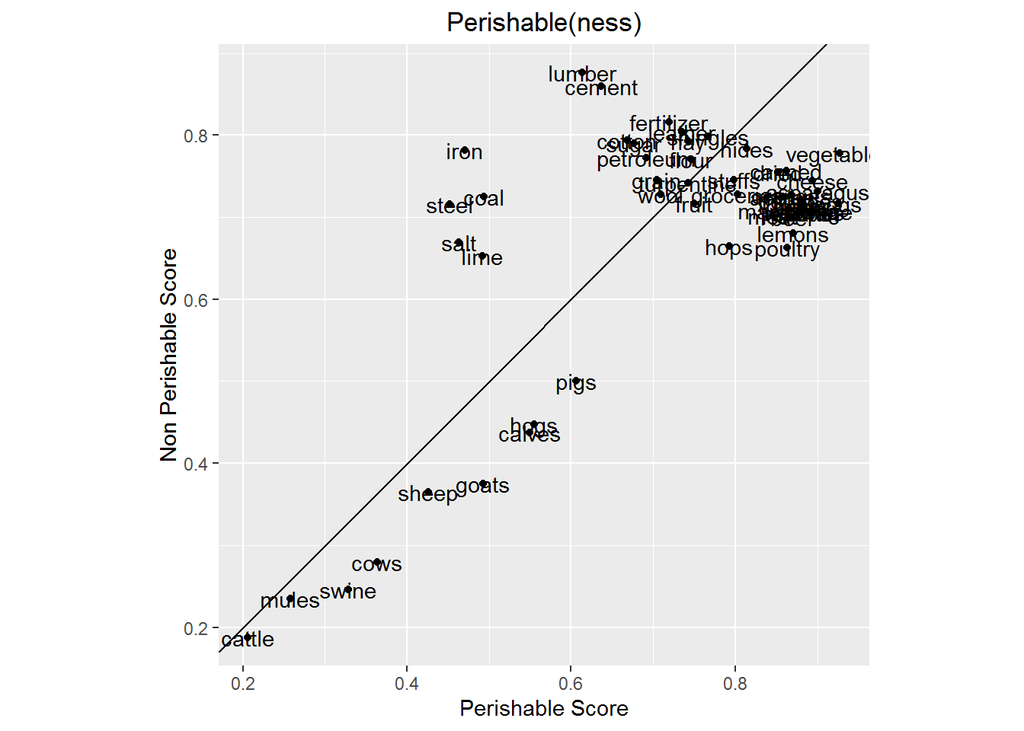

```r
ggplot (dfpvnp, aes(x, y, label = labels)) + geom_text() + geom_point() + coord_equal() + xlab("Perishable Score") + ylab("Non Perishable Score") + ggtitle("Perishable(ness)") + geom_abline(intercept = 0, slope = 1)
```

Below is a plot of alive(ness). Here the model did pretty well at locating the living animals. It also seperated organic and inorganic materials.

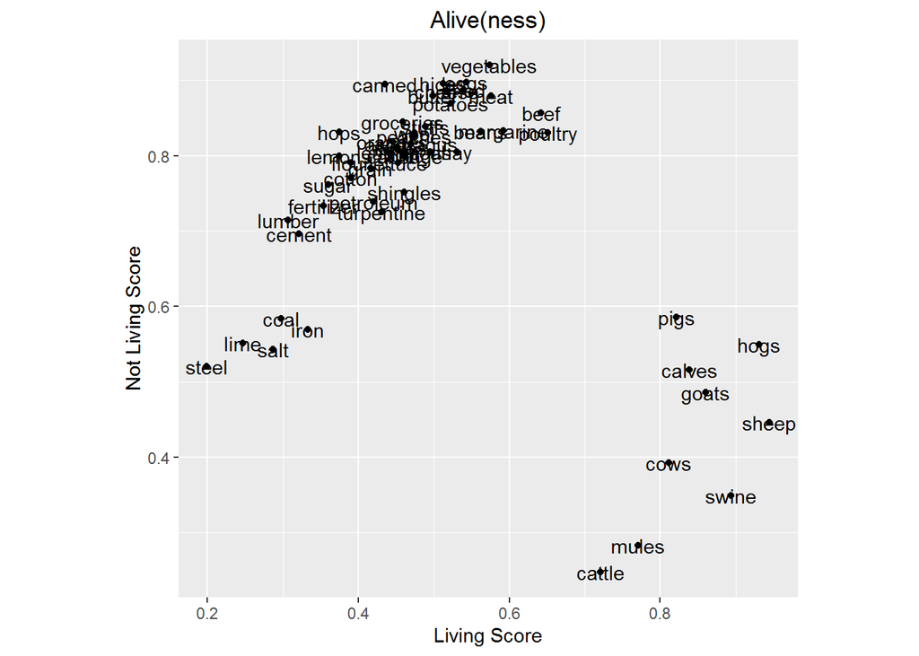

```r
ggplot (dflvnl, aes(x, y, label = labels)) + geom_text() + geom_point() + coord_equal() + xlab("Living Score") + ylab("Not Living Score") + ggtitle("Alive(ness)")
```

Below is a chart that combines the two sets of variables (living vs non perishable). Again the model does a good job of identifying living animals. It is even a bit unsure of where to place poultry which could refer to a shipment of living or dead chickens.

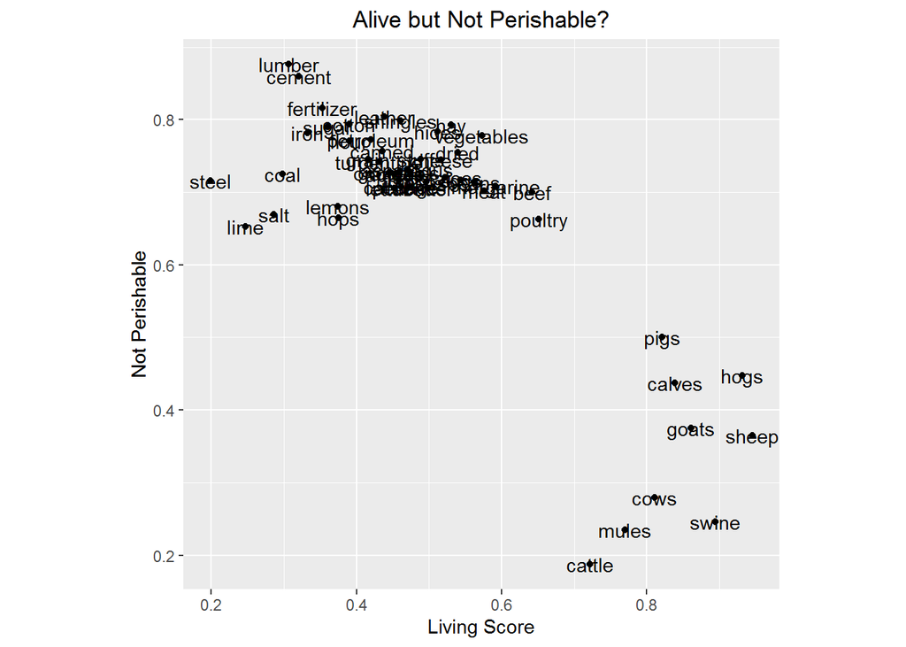

```r
ggplot (dflvnp, aes(x, y, label = labels)) + geom_text() + geom_point() + coord_equal() + xlab("Living Score") + ylab("Not Perishable") + ggtitle("Alive but Not Perishable?")
```

# Clustering

Simply plotting the enire railroad model shows some interesting clusters. For example, the words “negligence,”injury," “damage,” “jury,” and “defendent” are all clustered together.

[output not shown]

[output not shown]

[output not shown]

[output not shown]

[output not shown]

[output not shown]

[output not shown]

[output not shown]

[output not shown]

[output not shown]

[output not shown]

[output not shown]

[output not shown]

[output not shown]

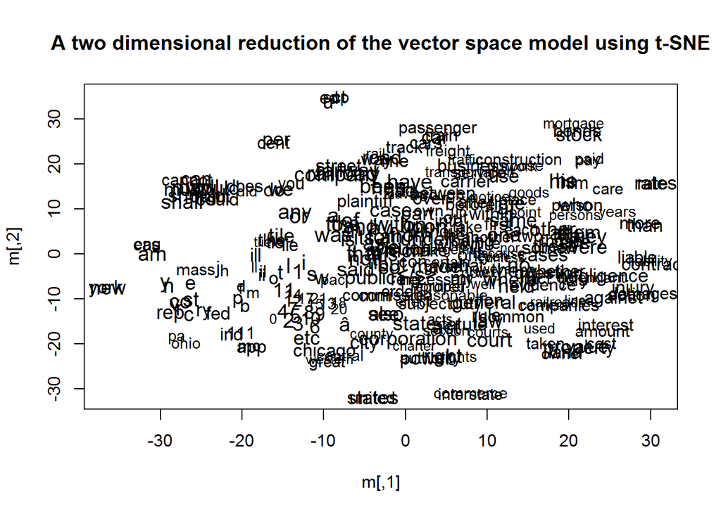

```r
plot(rr_model)
```

Similarity searching confirms the existence of this cluster.

```r
rr_model %>% nearest_to(rr_model[["injury"]])
```

```
##        injury      injuries        caused   proximately    occasioned
## -2.220446e-16  1.976743e-01  1.996868e-01  2.276643e-01  2.734206e-01
##          loss         death     negligent       causing       ilnjury
##  2.779366e-01  2.842562e-01  2.865560e-01  2.919026e-01  2.922064e-01
```